# COMPSCIX 415.2 Homework 5/Midterm

Gaurav Girdhar

7/6/2018

# 1 Section 1 - The Tidyverse Package

## 1.1 Question 1

1. Can you name which package is associated with each task below?

Plotting -

Data munging/wrangling -

Reshaping (speading and gathering) data -

Importing/exporting data -

## 1.2 Answer 1

Plotting - ggplot

Reshaping (spreading and gathering) data - tidyr

Importing & exporting Data - readr in tidyverse

## 1.3 Question 2

Now can you name two functions that you’ve used from each package that you listed above for these tasks?

Plotting -

Data munging/wrangling -

Reshaping data -

Importing/exporting data -

## 1.4 Answer 2

Plotting - geom_boxplot & geom_point

Data munging/wrangling - count & mutate

Reshaping data - gather & spread

Importing and Exporting Data - read_xxx & write_xxx

# 2 Section 2 - R Basics

## 2.1 Question 1

Fix this code with the fewest number of changes possible so it works:

My_data.name___is.too00ooLong! <- c( 1 , 2 , 3 )

## 2.2 Answer 1

```r
My_data.name___is.too00ooLong <- c( 1 , 2   , 3 )
My_data.name___is.too00ooLong
```

```
## [1] 1 2 3
```

## 2.3 Question 2

Fix this code so it works:

my_string <- C(‘has’, ‘an’, ‘error’, ‘in’, ’it)

## 2.4 Answer 2

Changed ‘C’ to ‘c’ & included the missing closing ’.

```r
my_string <- c('has', 'an', 'error', 'in', 'it')
my_string
```

```
## [1] "has"   "an"    "error" "in"    "it"
```

## 2.5 Question 3

Look at the code below and comment on what happened to the values in the vector.

my_vector <- c(1, 2, ‘3’, ‘4’, 5)

my_vector

## 2.6 Answer 3

```r
my_vector <- c(1, 2, '3', '4', 5)
my_vector
```

```
## [1] "1" "2" "3" "4" "5"
```

All the values are converted to Character by c()

# 3 Section 3 - Data import/export

## 3.1 Question 1

Download the rail_trail.txt file from Canvas (in the Midterm Exam section) and successfully import it into R. Prove that it was imported successfully by including your import code and taking a glimpse of the result.

```r
library(tidyverse)
file_path <- "rail_trail.txt"
railtrails <- read_delim(file = file_path, delim = "|")
glimpse(railtrails)
```

```
## Observations: 90
## Variables: 10
## $ hightemp   <int> 83, 73, 74, 95, 44, 69, 66, 66, 80, 79, 78, 65, 41,...
## $ lowtemp    <int> 50, 49, 52, 61, 52, 54, 39, 38, 55, 45, 55, 48, 49,...
## $ avgtemp    <dbl> 66.5, 61.0, 63.0, 78.0, 48.0, 61.5, 52.5, 52.0, 67....
## $ spring     <int> 0, 0, 1, 0, 1, 1, 1, 1, 0, 0, 0, 1, 1, 0, 0, 1, 0, ...
## $ summer     <int> 1, 1, 0, 1, 0, 0, 0, 0, 1, 1, 1, 0, 0, 0, 0, 0, 1, ...
## $ fall       <int> 0, 0, 0, 0, 0, 0, 0, 0, 0, 0, 0, 0, 0, 1, 1, 0, 0, ...
## $ cloudcover <dbl> 7.6, 6.3, 7.5, 2.6, 10.0, 6.6, 2.4, 0.0, 3.8, 4.1, ...
## $ precip     <dbl> 0.00, 0.29, 0.32, 0.00, 0.14, 0.02, 0.00, 0.00, 0.0...
## $ volume     <int> 501, 419, 397, 385, 200, 375, 417, 629, 533, 547, 4...
## $ weekday    <int> 1, 1, 1, 0, 1, 1, 1, 0, 0, 1, 1, 1, 1, 1, 1, 1, 0, ...
```

## 3.2 Question 2

Export the file into a comma-separated file and name it “rail_trail.csv”. Make sure you define the path correctly so that you know where it gets saved. Then reload the file. Include your export and import code and take another glimpse

## 3.3 Answer 2

```r
write_csv(railtrails, path = 'rail_trail.csv')
file_path <- 'rail_trail.csv'
railtrails <- read_csv(file = file_path)
glimpse(railtrails)
```

```
## Observations: 90
## Variables: 10
## $ hightemp   <int> 83, 73, 74, 95, 44, 69, 66, 66, 80, 79, 78, 65, 41,...
## $ lowtemp    <int> 50, 49, 52, 61, 52, 54, 39, 38, 55, 45, 55, 48, 49,...
## $ avgtemp    <dbl> 66.5, 61.0, 63.0, 78.0, 48.0, 61.5, 52.5, 52.0, 67....
## $ spring     <int> 0, 0, 1, 0, 1, 1, 1, 1, 0, 0, 0, 1, 1, 0, 0, 1, 0, ...
## $ summer     <int> 1, 1, 0, 1, 0, 0, 0, 0, 1, 1, 1, 0, 0, 0, 0, 0, 1, ...
## $ fall       <int> 0, 0, 0, 0, 0, 0, 0, 0, 0, 0, 0, 0, 0, 1, 1, 0, 0, ...
## $ cloudcover <dbl> 7.6, 6.3, 7.5, 2.6, 10.0, 6.6, 2.4, 0.0, 3.8, 4.1, ...
## $ precip     <dbl> 0.00, 0.29, 0.32, 0.00, 0.14, 0.02, 0.00, 0.00, 0.0...
## $ volume     <int> 501, 419, 397, 385, 200, 375, 417, 629, 533, 547, 4...
## $ weekday    <int> 1, 1, 1, 0, 1, 1, 1, 0, 0, 1, 1, 1, 1, 1, 1, 1, 0, ...
```

Note : Filepath is set automatically by R Studio to the directory where .Rmd is.

# 4 Section 4 - Visualization

## 4.4 Answer 2

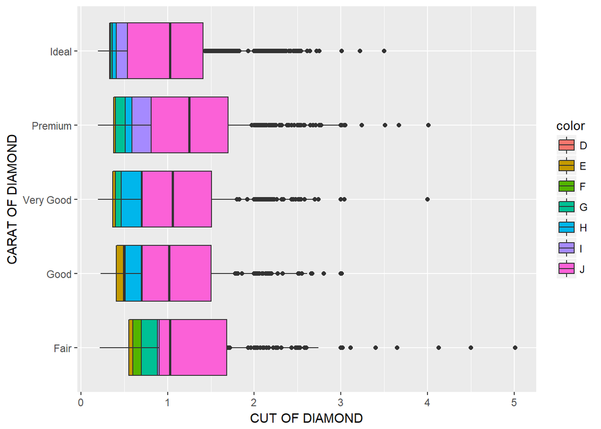

```r
library(tidyverse)
ggplot(data = diamonds, mapping = aes(factor(cut), carat, fill =  color)) +
  geom_boxplot(position = "identity") +
  xlab ("CARAT OF DIAMOND") +
  ylab ("CUT OF DIAMOND") +
  coord_flip()
```

## 4.5 Question 3

The previous graphic is not very useful. We can make it much more useful by changing one thing about it. Make the change and plot it again.

## 4.6 Answer 3

Remove position parameter from boxplot

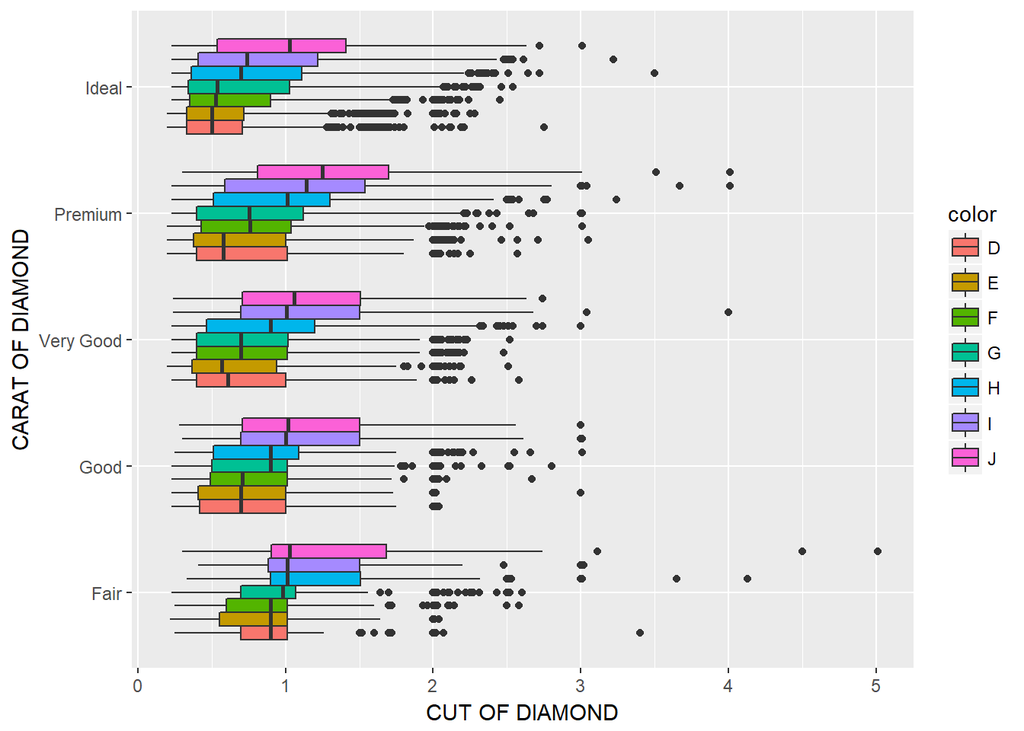

```r
library(tidyverse)
ggplot(data = diamonds, mapping = aes(factor(cut), carat, fill =  color)) +
  geom_boxplot() +
  xlab ("CARAT OF DIAMOND") +
  ylab ("CUT OF DIAMOND") +
  coord_flip()
```

# 5 Section 5 - Data Munging and Wrangling

## 5.1 Question 1

Is this data “tidy”? If yes, leave it alone and go to the next problem. If no, make it tidy. Note: this data set is called table2 and is available in the tidyverse package. It should be ready for you to use after you’ve loaded the tidyverse package.

```r
table2
```

```
## # A tibble: 12 x 4
##    country      year type            count
##    <chr>       <int> <chr>           <int>
##  1 Afghanistan  1999 cases             745
##  2 Afghanistan  1999 population   19987071
##  3 Afghanistan  2000 cases            2666
##  4 Afghanistan  2000 population   20595360
##  5 Brazil       1999 cases           37737
##  6 Brazil       1999 population  172006362
##  7 Brazil       2000 cases           80488
##  8 Brazil       2000 population  174504898
##  9 China        1999 cases          212258
## 10 China        1999 population 1272915272
## 11 China        2000 cases          213766
## 12 China        2000 population 1280428583
```

## 5.2 Answer 1

The data is not tidy.

```r
table2 %>%
    spread(key = type, value = count)
```

```
## # A tibble: 6 x 4
##   country      year  cases population
##   <chr>       <int>  <int>      <int>
## 1 Afghanistan  1999    745   19987071
## 2 Afghanistan  2000   2666   20595360
## 3 Brazil       1999  37737  172006362
## 4 Brazil       2000  80488  174504898
## 5 China        1999 212258 1272915272
## 6 China        2000 213766 1280428583
```

## 5.3 Question 2

Create a new column in the diamonds data set called price_per_carat that shows the price of each diamond per carat (hint: divide). Only show me the code, not the output.

## 5.4 Answer 2

transmute (diamonds, price_per_carat = price/carat)

```r
transmute (diamonds,
  price_per_carat = price/carat)
```

```
## # A tibble: 53,940 x 1
##    price_per_carat
##              <dbl>
##  1           1417.
##  2           1552.
##  3           1422.
##  4           1152.
##  5           1081.
##  6           1400
##  7           1400
##  8           1296.
##  9           1532.
## 10           1470.
## # ... with 53,930 more rows
```

## 5.5 Question 3

### 5.5.1 Question 3.1.1

For each cut of diamond in the diamonds data set, how many diamonds, and what proportion, have a price > 10000 and a carat < 1.5? There are several ways to get to an answer, but your solution must use the data wrangling verbs from the tidyverse in order to get credit.

### 5.5.2 Answer 3.1.1

```r
diamonds %>%
   filter(carat < 1.5 & price > 10000) %>%
   count(cut) %>%
   mutate(prop = n / sum(n)) %>%
   print(n = 30)
```

```
## # A tibble: 5 x 3
##   cut           n    prop
##   <ord>     <int>   <dbl>
## 1 Fair          4 0.00480
## 2 Good         17 0.0204
## 3 Very Good   155 0.186
## 4 Premium     173 0.207
## 5 Ideal       485 0.582
```

### 5.5.3 Question 3.1.2

Do the results make sense? Why?

### 5.5.4 Answer 3.1.2

The reult does make sense as all the number in each catogory are increasing as per the cut.

### 5.5.5 Question 3.1.3

Do we need to be wary of any of these numbers? Why?

### 5.5.6 Answer 3.1.3

Very Good and Premium are very close.

# 6 Section 4 - EDA

Take a look at the txhousing data set that is included with the ggplot2 package and answer these questions:

```r
glimpse(txhousing)
```

```
## Observations: 8,602
## Variables: 9
## $ city      <chr> "Abilene", "Abilene", "Abilene", "Abilene", "Abilene...
## $ year      <int> 2000, 2000, 2000, 2000, 2000, 2000, 2000, 2000, 2000...
## $ month     <int> 1, 2, 3, 4, 5, 6, 7, 8, 9, 10, 11, 12, 1, 2, 3, 4, 5...
## $ sales     <dbl> 72, 98, 130, 98, 141, 156, 152, 131, 104, 101, 100, ...
## $ volume    <dbl> 5380000, 6505000, 9285000, 9730000, 10590000, 139100...
## $ median    <dbl> 71400, 58700, 58100, 68600, 67300, 66900, 73500, 750...
## $ listings  <dbl> 701, 746, 784, 785, 794, 780, 742, 765, 771, 764, 72...
## $ inventory <dbl> 6.3, 6.6, 6.8, 6.9, 6.8, 6.6, 6.2, 6.4, 6.5, 6.6, 6....
## $ date      <dbl> 2000.000, 2000.083, 2000.167, 2000.250, 2000.333, 20...
```

## 6.1 Question 1

During what time period is this data from?

## 6.2 Answer 1

The Data is between 2000 & 2015

## 6.3 Question 2

How many cities are represented?

## 6.4 Answer 2

```r
txhousing %>%
  count(city)
```

```
## # A tibble: 46 x 2
##    city                      n
##    <chr>                 <int>
##  1 Abilene                 187
##  2 Amarillo                187
##  3 Arlington               187
##  4 Austin                  187
##  5 Bay Area                187
##  6 Beaumont                187
##  7 Brazoria County         187
##  8 Brownsville             187
##  9 Bryan-College Station   187
## 10 Collin County           187
## # ... with 36 more rows
```

There are total 46 Cities

## 6.9 Question 5

What proportion of sales is missing for each city?

## 6.10 Answer 5

```r
txhousing %>%
   filter(is.na(sales)) %>%
   count(city) %>%
   mutate(prop = n / sum(n)) %>%
   print(n = 30)
```

```
## # A tibble: 20 x 3
##    city                   n    prop
##    <chr>              <int>   <dbl>
##  1 Brazoria County       14 0.0246
##  2 Brownsville            2 0.00352
##  3 Corpus Christi         1 0.00176
##  4 Galveston              1 0.00176
##  5 Harlingen             25 0.0440
##  6 Kerrville            104 0.183
##  7 Killeen-Fort Hood      1 0.00176
##  8 Laredo                36 0.0634
##  9 Longview-Marshall     12 0.0211
## 10 Lubbock                1 0.00176
## 11 McAllen                2 0.00352
## 12 Midland               75 0.132
## 13 Nacogdoches           11 0.0194
## 14 Odessa                72 0.127
## 15 Port Arthur            2 0.00352
## 16 San Marcos            46 0.0810
## 17 South Padre Island   116 0.204
## 18 Temple-Belton         11 0.0194
## 19 Texarkana             17 0.0299
## 20 Waco                  19 0.0335
```

## 6.11 Question 6

Looking at only the cities and months with greater than 500 sales:

```r
txhousing %>%
   filter(sales > 500) %>%
   select(city, month, sales)
```

```
## # A tibble: 1,883 x 3
##    city      month sales
##    <chr>     <int> <dbl>
##  1 Arlington     8   507
##  2 Arlington     5   536
##  3 Arlington     6   534
##  4 Arlington     8   505
##  5 Arlington     5   503
##  6 Arlington     7   509
##  7 Arlington     5   502
##  8 Arlington     7   524
##  9 Arlington     8   531
## 10 Arlington     5   527
## # ... with 1,873 more rows
```

Any cities that stand out that you’d want to investigate further?

Why might we want to filter out all cities and months with sales less than 500?